# Loan Data (from Prosper) Exploration

- What is/are the main feature(s) of interest in your dataset?
- Preliminary Wrangling
- Univariate Exploration of Data
- Question 1: What is the trend of the `LoanStatus` variable ?
- Question 2: What The most used `CreditGrade` ?
- Question 3: The most contracted loan `Term` ?
- Question 4: `BorrowerAPR` distribution
- Question 5: `ProsperRating` distribution
- Question 6: `ProsperScore` distribution
- Question 7: `ListingCategory` distribution
- Question 8: `Investors` distribution
- Question 9: `EmploymentStatus`, `Occupation`, `EmploymentStatusDuration` and `IsBorrowerHomeowner` distribution
- Question 10: `IncomeRange` distribution
- Univariate Exploration Summary
- Bivariate Exploration of Data
- Question 1: Relationship between `BorrowerAPR` and `BorrowerState`
- Question 2: Relationship between `ProsperRating (Alpha)` and `ProsperScore`
- Question 3: Relationship between `ProsperScore` and `ProsperRating (numeric)`
- Question 4: Relationship between `Term` and `BorrowerState`
- Question 5: Relationship between `BorrowerState` per `ProsperScore`
- Bivariate Exploration Summary
- Multivariate Exploration of Data
- Question 1: Relationship between `ProsperScore` and `BorrowerAPR` per `ProsperRating (Alpha)`
- Question 2: Relationship between `ProsperScore` and `LenderYield` per `ProsperRating (Alpha)`
- Question 3: Relationship between `LoanOriginalAmount` and `BorrowerAPR` per `ProsperRating (Alpha)` per `IncomeRange`
- Multivariate Exploration Summary
- Conclusions
- Feedback

## What is/are the main feature(s) of interest in your dataset?

I don't know now but I expect to find out what features can explain loans interest.

What factors affect a loan’s outcome status?

What affects the borrower’s APR or interest rate?

Are there differences between loans depending on how large the original loan amount was?

## Preliminary Wrangling

This data set contains 113,937 loans with 81 variables on each loan, including loan amount, borrower rate (or interest rate), current loan status, borrower income, and many others.

- This data dictionary explains the variables in the data set.
- You are not expected to explore all of the variables in the dataset! Focus your exploration on about 10-15 of them.

```python
import numpy as np
import pandas as pd
import matplotlib.pyplot as plt
import seaborn as sns
%matplotlib inline
```

unicodedecodeerror-utf-8-codec-while-reading-a-csv-file

```python
prosperLoanData = pd.read_csv('prosperLoanData.csv', encoding='utf-8', engine='python')
```

We need to expand the number of displayable columns so it fits the number of columns of the DataFrame which is 81.

how-do-i-expand-the-output-display-to-see-more-columns-of-a-pandas-dataframe

```python
pd.set_option('display.max_rows', 50)
pd.set_option('display.max_columns', 81)
#pd.set_option('display.width', 1000)
```

```python
prosperLoanData.head(10)
```

|  | ListingKey | ListingNumber | ListingCreationDate | CreditGrade | Term | LoanStatus | ClosedDate | BorrowerAPR | BorrowerRate | LenderYield | EstimatedEffectiveYield | EstimatedLoss | EstimatedReturn | ProsperRating (numeric) | ProsperRating (Alpha) | ProsperScore | ListingCategory (numeric) | BorrowerState | Occupation | EmploymentStatus | EmploymentStatusDuration | IsBorrowerHomeowner | CurrentlyInGroup | GroupKey | DateCreditPulled | CreditScoreRangeLower | CreditScoreRangeUpper | FirstRecordedCreditLine | CurrentCreditLines | … |
| --- | --- | --- | --- | --- | --- | --- | --- | --- | --- | --- | --- | --- | --- | --- | --- | --- | --- | --- | --- | --- | --- | --- | --- | --- | --- | --- | --- | --- | --- | --- |
| 0 | 1021339766868145413AB3B | 193129 | 2007-08-26 19:09:29.263000000 | C | 36 | Completed | 2009-08-14 00:00:00 | 0.16516 | 0.1580 | 0.1380 | NaN | NaN | NaN | NaN | NaN | NaN | 0 | CO | Other | Self-employed | 2.0 | True | True | NaN | 2007-08-26 18:41:46.780000000 | 640.0 | 659.0 | 2001-10-11 00:00:00 | 5.0 | … |
| 1 | 10273602499503308B223C1 | 1209647 | 2014-02-27 08:28:07.900000000 | NaN | 36 | Current | NaN | 0.12016 | 0.0920 | 0.0820 | 0.07960 | 0.0249 | 0.05470 | 6.0 | A | 7.0 | 2 | CO | Professional | Employed | 44.0 | False | False | NaN | 2014-02-27 08:28:14 | 680.0 | 699.0 | 1996-03-18 00:00:00 | 14.0 | … |
| 2 | 0EE9337825851032864889A | 81716 | 2007-01-05 15:00:47.090000000 | HR | 36 | Completed | 2009-12-17 00:00:00 | 0.28269 | 0.2750 | 0.2400 | NaN | NaN | NaN | NaN | NaN | NaN | 0 | GA | Other | Not available | NaN | False | True | 783C3371218786870A73D20 | 2007-01-02 14:09:10.060000000 | 480.0 | 499.0 | 2002-07-27 00:00:00 | NaN | … |
| 3 | 0EF5356002482715299901A | 658116 | 2012-10-22 11:02:35.010000000 | NaN | 36 | Current | NaN | 0.12528 | 0.0974 | 0.0874 | 0.08490 | 0.0249 | 0.06000 | 6.0 | A | 9.0 | 16 | GA | Skilled Labor | Employed | 113.0 | True | False | NaN | 2012-10-22 11:02:32 | 800.0 | 819.0 | 1983-02-28 00:00:00 | 5.0 | … |
| 4 | 0F023589499656230C5E3E2 | 909464 | 2013-09-14 18:38:39.097000000 | NaN | 36 | Current | NaN | 0.24614 | 0.2085 | 0.1985 | 0.18316 | 0.0925 | 0.09066 | 3.0 | D | 4.0 | 2 | MN | Executive | Employed | 44.0 | True | False | NaN | 2013-09-14 18:38:44 | 680.0 | 699.0 | 2004-02-20 00:00:00 | 19.0 | … |
| 5 | 0F05359734824199381F61D | 1074836 | 2013-12-14 08:26:37.093000000 | NaN | 60 | Current | NaN | 0.15425 | 0.1314 | 0.1214 | 0.11567 | 0.0449 | 0.07077 | 5.0 | B | 10.0 | 1 | NM | Professional | Employed | 82.0 | True | False | NaN | 2013-12-14 08:26:40 | 740.0 | 759.0 | 1973-03-01 00:00:00 | 21.0 | … |
| 6 | 0F0A3576754255009D63151 | 750899 | 2013-04-12 09:52:56.147000000 | NaN | 36 | Current | NaN | 0.31032 | 0.2712 | 0.2612 | 0.23820 | 0.1275 | 0.11070 | 2.0 | E | 2.0 | 1 | KS | Sales - Retail | Employed | 172.0 | False | False | NaN | 2013-04-12 09:52:53 | 680.0 | 699.0 | 2000-09-29 00:00:00 | 10.0 | … |
| 7 | 0F1035772717087366F9EA7 | 768193 | 2013-05-05 06:49:27.493000000 | NaN | 36 | Current | NaN | 0.23939 | 0.2019 | 0.1919 | 0.17830 | 0.0799 | 0.09840 | 4.0 | C | 4.0 | 2 | CA | Laborer | Employed | 103.0 | False | False | NaN | 2013-05-05 06:49:25 | 700.0 | 719.0 | 1999-02-25 00:00:00 | 6.0 | … |
| 8 | 0F043596202561788EA13D5 | 1023355 | 2013-12-02 10:43:39.117000000 | NaN | 36 | Current | NaN | 0.07620 | 0.0629 | 0.0529 | 0.05221 | 0.0099 | 0.04231 | 7.0 | AA | 9.0 | 7 | IL | Food Service | Employed | 269.0 | True | False | NaN | 2013-12-02 10:43:39 | 820.0 | 839.0 | 1993-04-01 00:00:00 | 17.0 | … |
| 9 | 0F043596202561788EA13D5 | 1023355 | 2013-12-02 10:43:39.117000000 | NaN | 36 | Current | NaN | 0.07620 | 0.0629 | 0.0529 | 0.05221 | 0.0099 | 0.04231 | 7.0 | AA | 11.0 | 7 | IL | Food Service | Employed | 269.0 | True | False | NaN | 2013-12-02 10:43:39 | 820.0 | 839.0 | 1993-04-01 00:00:00 | 17.0 | … |

```python
# Getting basic informations about the dataset
prosperLoanData.info()
```

```
<class 'pandas.core.frame.DataFrame'>
RangeIndex: 113937 entries, 0 to 113936
Data columns (total 81 columns):
 #   Column                               Non-Null Count   Dtype
---  ------                               --------------   -----
 0   ListingKey                           113937 non-null  object
 1   ListingNumber                        113937 non-null  int64
 2   ListingCreationDate                  113937 non-null  object
 3   CreditGrade                          28953 non-null   object
 4   Term                                 113937 non-null  int64
 5   LoanStatus                           113937 non-null  object
 6   ClosedDate                           55089 non-null   object
 7   BorrowerAPR                          113912 non-null  float64
 8   BorrowerRate                         113937 non-null  float64
 9   LenderYield                          113937 non-null  float64
```

[output cut: 73 more lines]

## Univariate Exploration of Data

### Question 1: What is the trend of the `LoanStatus` variable ?

We'll start looking at the trend of the `LoanStatus` variable.

`LoanStatus` : The current status of the loan: Cancelled, Chargedoff, Completed, Current, Defaulted, FinalPaymentInProgress, PastDue. The PastDue status will be accompanied by a delinquency bucket.

```python
def special_barplot(data, colname):
    """This fuction will help to plot bar charts with percentage of each bar overall the data for better insights."""
    # Getting order from the greatest to the lowest
    prosperLoanData = data
    col_name = colname

    type_counts = prosperLoanData[col_name].value_counts()
    order = type_counts.index
    n_total = type_counts.sum()
    color = sns.color_palette()[0]
    plt.figure(figsize = (15, 10))
    f = sns.countplot(data=prosperLoanData, y=col_name, order=order, color=color);
    try:
        for index in range(type_counts.shape[0]):
            count = type_counts[index]
            percent_str = f'{100 * count / n_total:0.2f}%'
            plt.text(x=count+3, y=index, s=percent_str, va='center', fontdict={'fontsize': 15});

        xticks = list(type_counts.values)[::-1]
        #print(xticks)
        xlabels = [f'{elt:0.1f}' for elt in xticks]
        yticks = list(type_counts.index)
        #print(yticks)
        ylabels = [f'{elt}' for elt in yticks]
        #plt.xticks(ticks=xticks, labels=xlabels, rotation=30)
        plt.yticks(ticks=np.arange(len(yticks)), labels=ylabels, rotation=60)
    except Exception as e :
        #print(e)
        pass
```

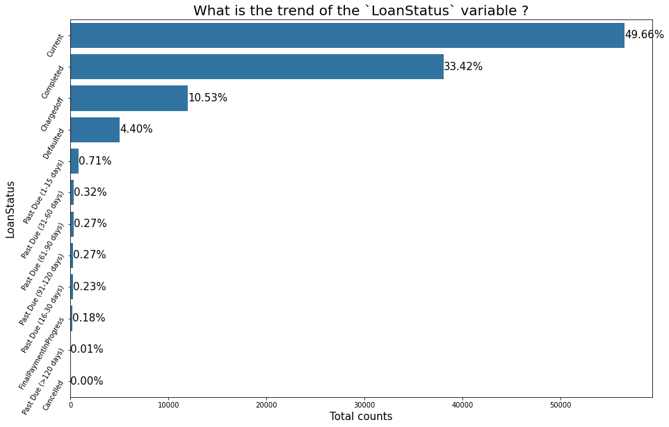

```python
special_barplot(data=prosperLoanData, colname='LoanStatus')
#f.set_xticklabels(labels = list(type_counts.values), minor=True, rotation=360)
plt.title('What is the trend of the `LoanStatus` variable ?', fontdict={'fontsize': 20});
plt.xlabel(xlabel='Total counts', fontdict={'fontsize': 15});
plt.ylabel(ylabel='LoanStatus', fontdict={'fontsize': 15});
```

- As we can see, most of the loans are ongoing `49.66%`, some are already completed `33.42%` and the less are chargedoff `10.53%`. All the other statuses are not so relevant because they have little percentages.

### Question 2: What The most used `CreditGrade` ?

`CreditGrade` : The Credit rating that was assigned at the time the listing went live. Applicable for listings pre-2009 period and will only be populated for those listings.

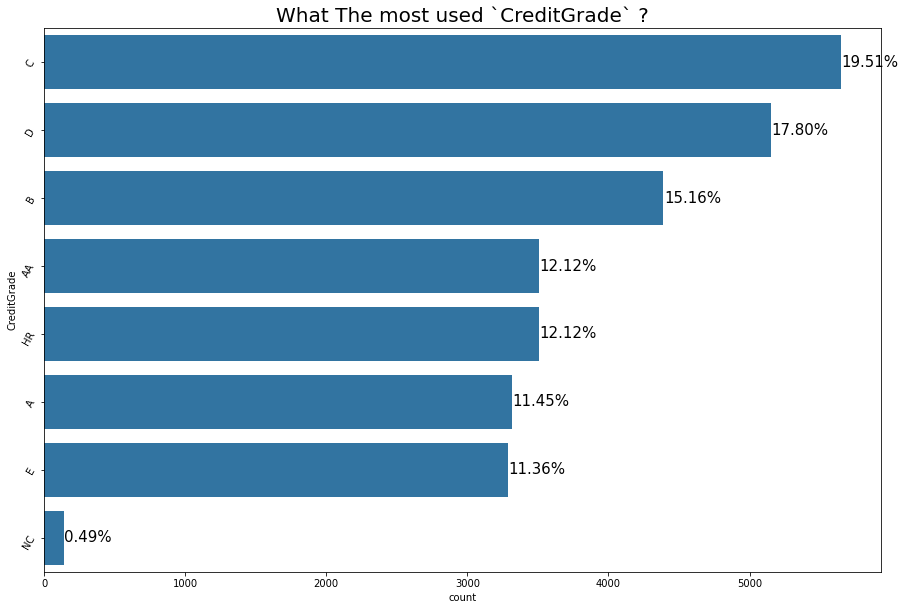

```python
special_barplot(data=prosperLoanData, colname='CreditGrade');
plt.title('What The most used `CreditGrade` ?', fontdict={'fontsize': 20});
```

- The grade `C` is the most represented with `19.51%`
- The grade `D` is the second most represented with `17.80%`
- The grade `B` is the third most represented with `15.16%`

### Question 3: The most contracted loan `Term` ?

`Term` : The length of the loan expressed in months.

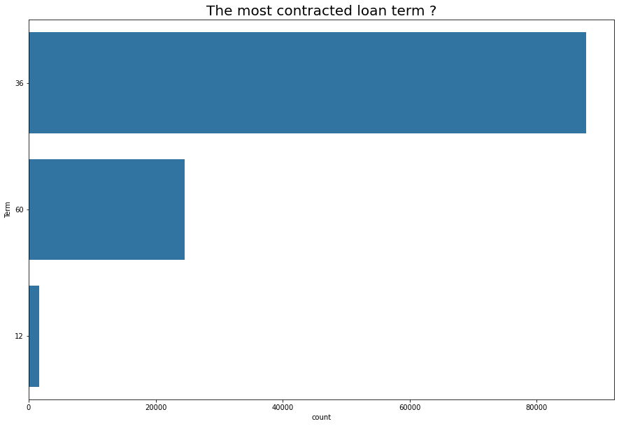

```python
special_barplot(data=prosperLoanData, colname='Term');
plt.title('The most contracted loan term ?', fontdict={'fontsize': 20});
```

The most contracted loan term is the length of `36 months` with more than 80000 contracts.

### Question 4: `BorrowerAPR` distribution

`BorrowerAPR` : The Borrower's Annual Percentage Rate (APR) for the loan.

```python
prosperLoanData['BorrowerAPR'].describe()
```

```
count    113912.000000
mean          0.218828
std           0.080364
min           0.006530
25%           0.156290
50%           0.209760
75%           0.283810
max           0.512290
Name: BorrowerAPR, dtype: float64
```

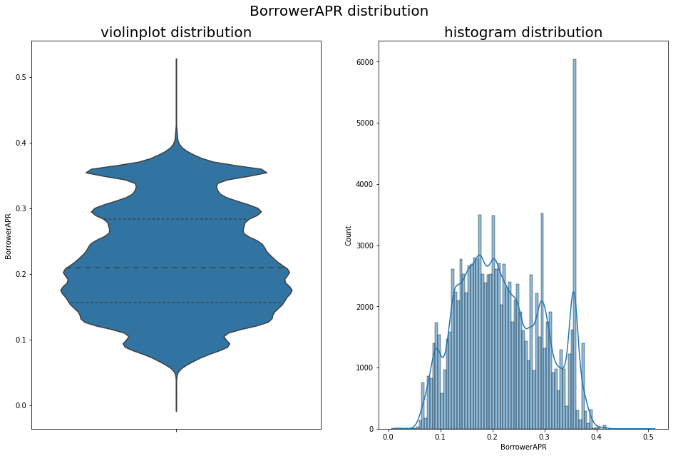

```python
plt.figure(figsize = (16, 10));
plt.suptitle('BorrowerAPR distribution', x=0.5, y=0.95, fontproperties={'size': 20});
plt.subplot(1, 2, 1)
sns.violinplot(data=prosperLoanData, y='BorrowerAPR', inner='quartile');
plt.title('violinplot distribution', fontdict={'fontsize': 20});
plt.subplot(1, 2, 2)
sns.histplot(data=prosperLoanData, x='BorrowerAPR', kde=True);
plt.title('histogram distribution', fontdict={'fontsize': 20});
```

- The distribution is slightly normal
- With a standard deviation of `0.080364` the median value of the BorrowerAPR is `0.209760` and it is closest to the mean `0.218828`. It means that the BorrowerAPR is really good for loans.

### Question 5: `ProsperRating` distribution

`ProsperRating (Alpha)` : The Prosper Rating assigned at the time the listing was created between AA - HR. Applicable for loans originated after July 2009.

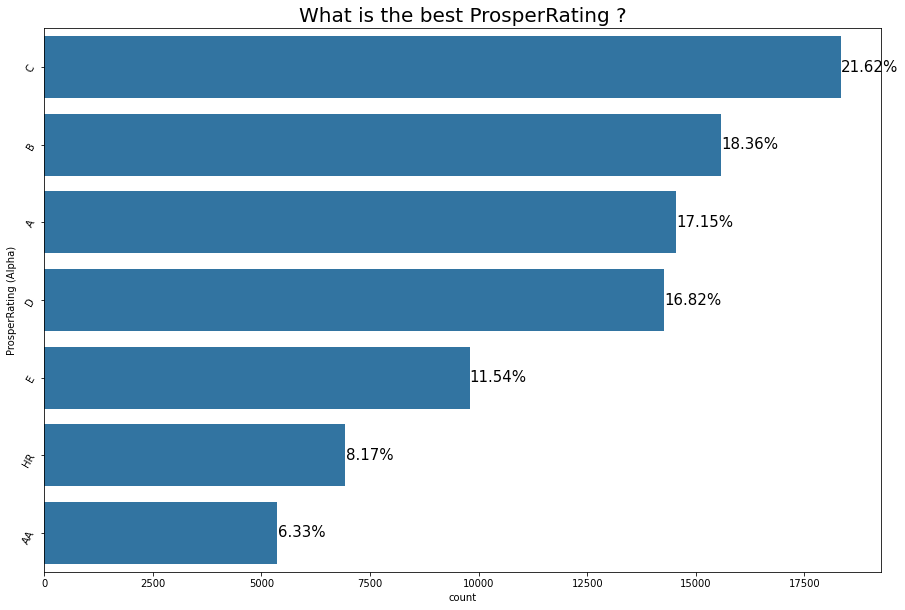

```python
special_barplot(data=prosperLoanData, colname='ProsperRating (Alpha)');
plt.title('What is the best ProsperRating ?', fontdict={'fontsize': 20});
```

The best ProsperRating is

- The grade `C` is the most represented with `21.62%` and followed by
- The grade `B` is the second most represented with `18.36%` and followed by
- The grade `A` is the third most represented with `17.15%`

### Question 6: `ProsperScore` distribution

`ProsperScore` : A custom risk score built using historical Prosper data. The score ranges from 1-10, with 10 being the best, or lowest risk score. Applicable for loans originated after July 2009.

```python
prosperLoanData['ProsperScore'].describe()
```

```
count    84853.000000
mean         5.950067
std          2.376501
min          1.000000
25%          4.000000
50%          6.000000
75%          8.000000
max         11.000000
Name: ProsperScore, dtype: float64
```

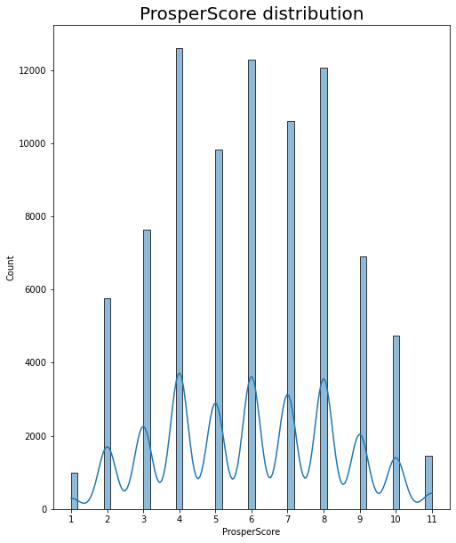

```python
plt.figure(figsize = (8, 10));
sns.histplot(data=prosperLoanData, x='ProsperScore', kde=True);
plt.xticks(ticks=range(1, 11 + 1), labels=[f'{i}' for i in range(1, 11 + 1)])
plt.title('ProsperScore distribution', fontdict={'fontsize': 20});
```

- The most highest `ProsperScore` are `4` then `6` then `8`. More than 12000 loans are relataed to houses with such ProsperScore.

### Question 7: `ListingCategory` distribution

`ListingCategory` : The category of the listing that the borrower selected when posting their listing: 0 - Not Available, 1 - Debt Consolidation, 2 - Home Improvement, 3 - Business, 4 - Personal Loan, 5 - Student Use, 6 - Auto, 7- Other, 8 - Baby&Adoption, 9 - Boat, 10 - Cosmetic Procedure, 11 - Engagement Ring, 12 - Green Loans, 13 - Household Expenses, 14 - Large Purchases, 15 - Medical/Dental, 16 - Motorcycle, 17 - RV, 18 - Taxes, 19 - Vacation, 20 - Wedding Loans

```python
prosperLoanData['ListingCategory (numeric)'].describe()
```

```
count    113937.000000
mean          2.774209
std           3.996797
min           0.000000
25%           1.000000
50%           1.000000
75%           3.000000
max          20.000000
Name: ListingCategory (numeric), dtype: float64
```

```python
# Creating a dict for ListingCategory
ListingCategoryDict ={0 : 'Not Available', 1 : 'Debt Consolidation', 2 : 'Home Improvement', 3 : 'Business', 4 : 'Personal Loan', 5 : 'Student Use', 6 : 'Auto', 7 : 'Other', 8 : 'Baby&Adoption', 9 : 'Boat', 10 : 'Cosmetic Procedure', 11 : 'Engagement Ring', 12 : 'Green Loans', 13 : 'Household Expenses', 14 : 'Large Purchases', 15 : 'Medical/Dental', 16 : 'Motorcycle', 17 : 'RV', 18 : 'Taxes', 19 : 'Vacation', 20 : 'Wedding Loans'}
```

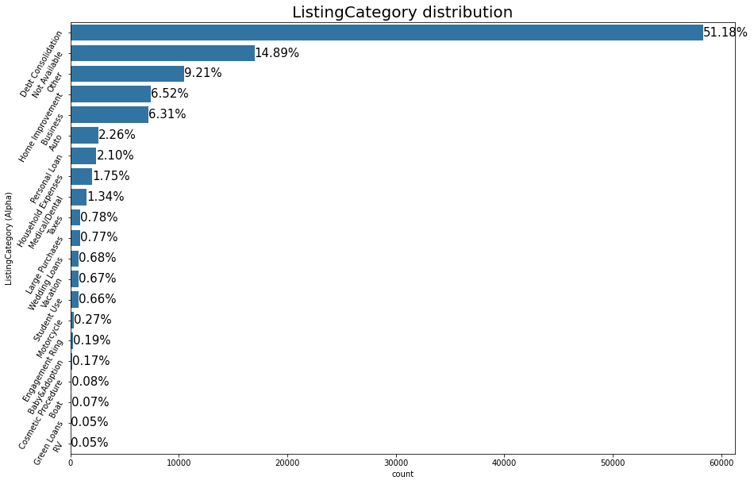

```python
#plt.figure(figsize = (8, 10));
# Creating a variable for coresponding listing category numbers to their meaning.
prosperLoanData['ListingCategory (Alpha)'] = prosperLoanData['ListingCategory (numeric)'].apply(lambda val: ListingCategoryDict[val]);
special_barplot(data=prosperLoanData, colname='ListingCategory (Alpha)');
plt.title('ListingCategory distribution', fontdict={'fontsize': 20});
```

Most of the loans are for `Debt Consolidation`. Really inspiring.

### Question 8: `Investors` distribution

`Investors` : The number of investors that funded the loan.

```python
prosperLoanData['Investors'].value_counts().nlargest(5)
```

```
1    27814
2     1386
3      991
4      827
5      753
Name: Investors, dtype: int64
```

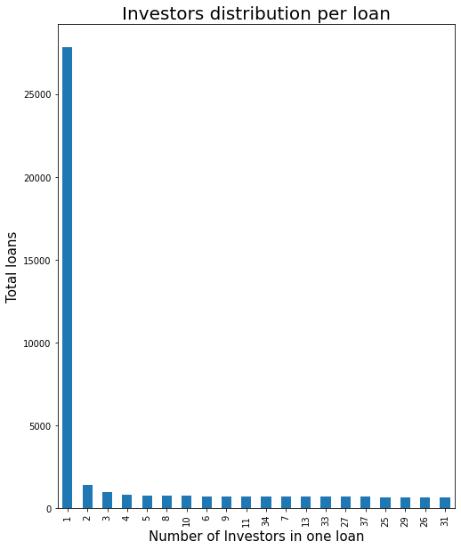

```python
plt.figure(figsize = (8, 10));
prosperLoanData['Investors'].value_counts().nlargest(20).plot(kind='bar');
plt.title('Investors distribution per loan', fontdict={'fontsize': 20});
plt.xlabel(xlabel='Number of Investors in one loan', fontdict={'fontsize': 15});
plt.ylabel(ylabel='Total loans', fontdict={'fontsize': 15});
```

### Question 9: `EmploymentStatus`, `Occupation`, `EmploymentStatusDuration` and `IsBorrowerHomeowner` distribution

`EmploymentStatus` : The employment status of the borrower at the time they posted the listing.

`Occupation` : The Occupation selected by the Borrower at the time they created the listing.

`EmploymentStatusDuration` : The length in months of the employment status at the time the listing was created.

`IsBorrowerHomeowner` : A Borrower will be classified as a homowner if they have a mortgage on their credit profile or provide documentation confirming they are a homeowner.

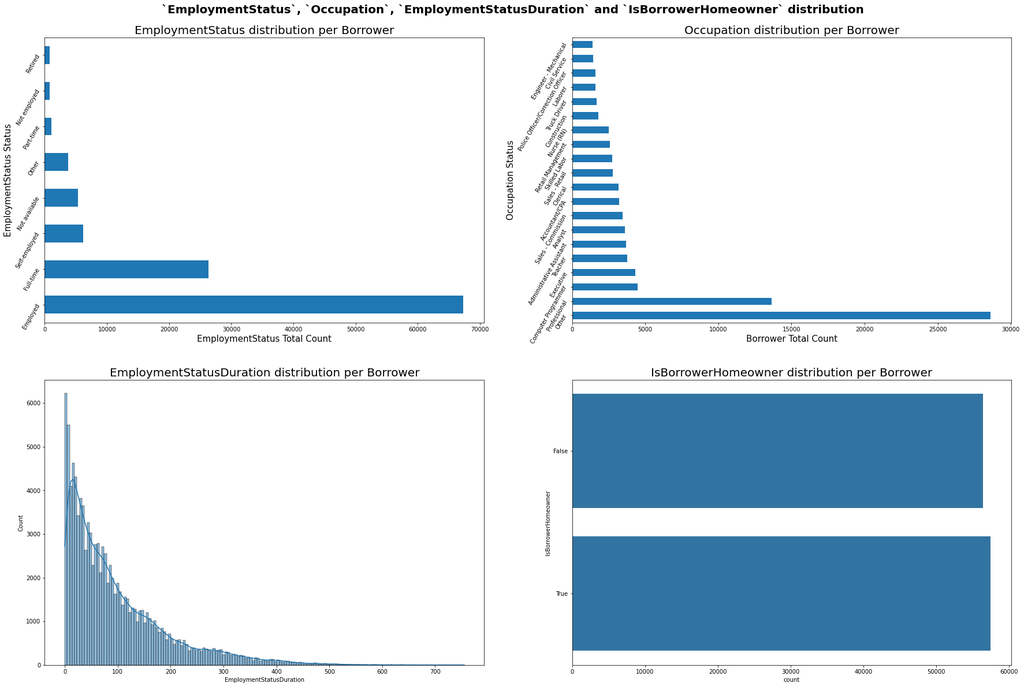

```python
plt.figure(figsize = (30, 20));
plt.suptitle('`EmploymentStatus`, `Occupation`, `EmploymentStatusDuration` and `IsBorrowerHomeowner` distribution', fontsize=20, fontweight='bold', x=0.5, y=0.92)

plt.subplot(2, 2, 1)
prosperLoanData['EmploymentStatus'].value_counts().nlargest(20).plot(kind='barh');
plt.title('EmploymentStatus distribution per Borrower', fontdict={'fontsize': 20});
plt.xlabel(xlabel='EmploymentStatus Total Count', fontdict={'fontsize': 15});
plt.ylabel(ylabel='EmploymentStatus Status', fontdict={'fontsize': 15});
plt.yticks(rotation=60);

plt.subplot(2, 2, 2)
prosperLoanData['Occupation'].value_counts().nlargest(20).plot(kind='barh');
plt.title('Occupation distribution per Borrower', fontdict={'fontsize': 20});
plt.xlabel(xlabel='Borrower Total Count', fontdict={'fontsize': 15});
plt.ylabel(ylabel='Occupation Status', fontdict={'fontsize': 15});
plt.yticks(rotation=60);

plt.subplot(2, 2, 3)
sns.histplot(data=prosperLoanData, x='EmploymentStatusDuration', kde=True);
plt.title('EmploymentStatusDuration distribution per Borrower', fontdict={'fontsize': 20});

plt.subplot(2, 2, 4);
sns.countplot(data=prosperLoanData, y='IsBorrowerHomeowner', color=sns.color_palette()[0]);
plt.title('IsBorrowerHomeowner distribution per Borrower', fontdict={'fontsize': 20});
```

### Question 10: `IncomeRange` distribution

`IncomeRange` : The income range of the borrower at the time the listing was created.

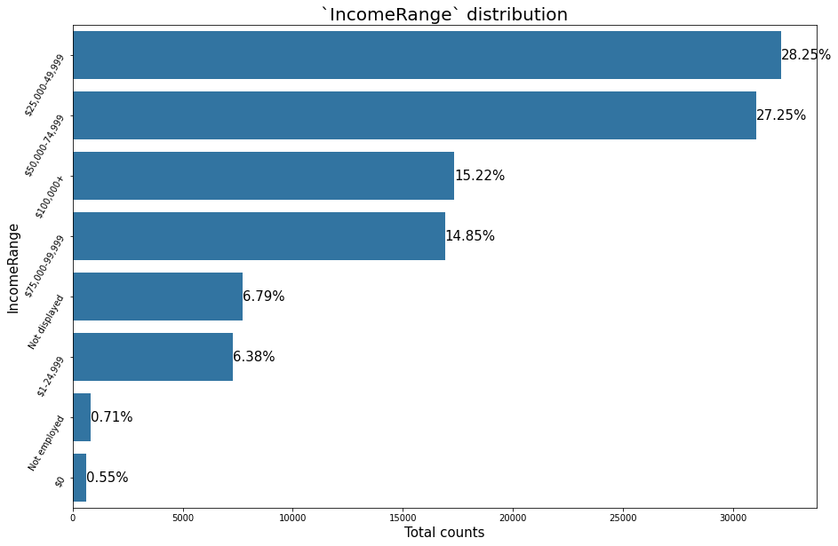

```python
special_barplot(data=prosperLoanData, colname='IncomeRange')
#f.set_xticklabels(labels = list(type_counts.values), minor=True, rotation=360)
plt.title('`IncomeRange` distribution', fontdict={'fontsize': 20});
plt.xlabel(xlabel='Total counts', fontdict={'fontsize': 15});
plt.ylabel(ylabel='IncomeRange', fontdict={'fontsize': 15});
```

### Univariate Exploration Summary

#### Question 1: What is the trend of the `LoanStatus` variable ?

- As we can see, most of the loans are ongoing `49.66%`, some are already completed `33.42%` and the less are chargedoff `10.53%`. All the other statuses are not so relevant because they have little percentages.

#### Question 2: What The most used `CreditGrade` ?

- The grade `C` is the most represented with `19.51%`
- The grade `D` is the second most represented with `17.80%`
- The grade `B` is the third most represented with `15.16%`

#### Question 3: The most contracted loan `Term` ?

- The most contracted loan term is the length of `36 months` with more than 80000 contracts.

#### Question 4: BorrowerAPR distribution

- The distribution is slightly normal
- With a standard deviation of `0.080364` the median value of the BorrowerAPR is `0.209760` and it is closest to the mean `0.218828`. It means that the BorrowerAPR is really good for loans.

#### Question 5: What is the best ProsperRating ?

The best ProsperRating is

- The grade `C` is the most represented with `21.62%` and followed by
- The grade `B` is the second most represented with `18.36%` and followed by
- The grade `A` is the third most represented with `17.15%`

#### Question 6: `ProsperScore` distribution

- The most highest `ProsperScore` are `4` then `6` then `8`. More than 12000 loans are relataed to houses with such ProsperScore.

#### Question 7: `ListingCategory` distribution

- Most of the loans are for `Debt Consolidation`. Really inspiring.

## Bivariate Exploration of Data

### Question 1: Relationship between `BorrowerAPR` and `BorrowerState`

`BorrowerAPR` : The Borrower's Annual Percentage Rate (APR) for the loan.

`BorrowerState` : The two letter abbreviation of the state of the address of the borrower at the time the Listing was created.

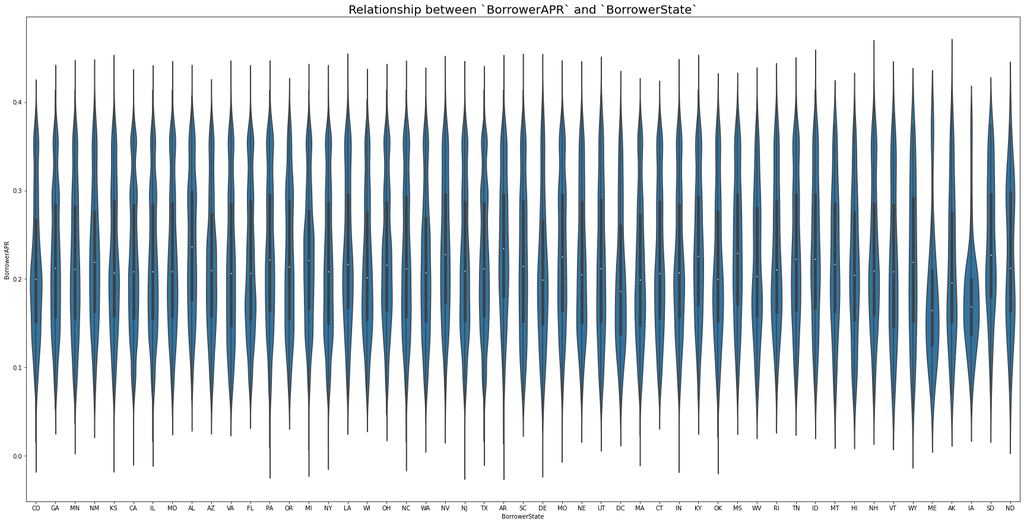

```python
color = sns.color_palette()[0]
plt.figure(figsize = (30, 15));
sns.violinplot(data=prosperLoanData, x='BorrowerState', y='BorrowerAPR', inner='box', color=color);
plt.title('Relationship between `BorrowerAPR` and `BorrowerState`', fontdict={'fontsize': 20});
```

Per each`BorrowerState`, the `BorrowerAPR` are slightly the same. There is not much difference of `BorrowerAPR` according to differents `BorrowerState`.

### Question 2: Relationship between `ProsperRating (Alpha)` and `ProsperScore`

`ProsperRating (Alpha)` : The Prosper Rating assigned at the time the listing was created between AA - HR. Applicable for loans originated after July 2009.

`ProsperScore` : A custom risk score built using historical Prosper data. The score ranges from 1-10, with 10 being the best, or lowest risk score. Applicable for loans originated after July 2009.

```python
# Let's convert ProsperRating (Alpha) to a CategoricalDtype
classes = ['N/A', 'HR', 'E', 'D', 'C', 'B', 'A', 'AA']
# Creating Category
cat_classes = pd.api.types.CategoricalDtype(categories=classes, ordered=True)
# Converting to CategoricalDtype
prosperLoanData['ProsperRating (Alpha)'] = prosperLoanData['ProsperRating (Alpha)'].astype(cat_classes)
# Testing
prosperLoanData['ProsperRating (Alpha)'].info()
```

```
<class 'pandas.core.series.Series'>
RangeIndex: 113937 entries, 0 to 113936
Series name: ProsperRating (Alpha)
Non-Null Count  Dtype
--------------  -----
84853 non-null  category
dtypes: category(1)
memory usage: 111.7 KB
```

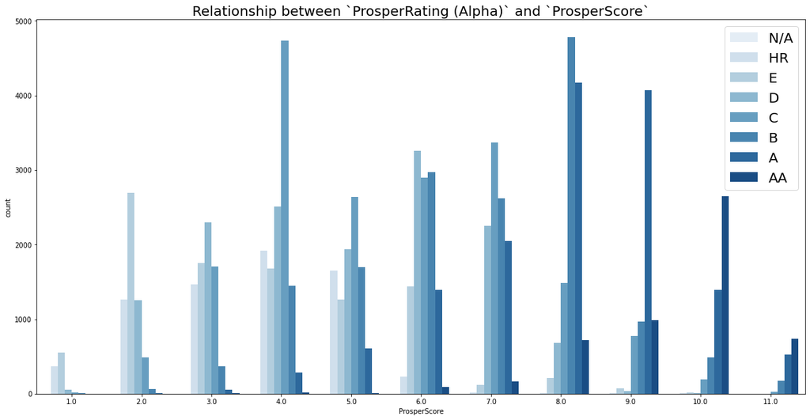

```python
color = sns.color_palette()[0]
plt.figure(figsize = (20, 10));
sns.countplot(data=prosperLoanData, x='ProsperScore', hue='ProsperRating (Alpha)', palette='Blues');
plt.legend(fontsize=20, loc='upper right');
plt.title('Relationship between `ProsperRating (Alpha)` and `ProsperScore`', fontdict={'fontsize': 20});
```

- Loans with high ProsperScore(like 8, 9 or 10) are associated with high ProsperRating(like B, A or AA)
- Loans with median ProsperScore(like 5, 6 or 7) are associated with low or median ProsperRating(like E, D or C)
- Loans with low ProsperScore(like 1, 2 or 4) are associated with low ProsperRating(like HR, E or D)

### Question 3: Relationship between `ProsperScore` and `ProsperRating (numeric)`

`ProsperRating (numeric)` : The Prosper Rating assigned at the time the listing was created: 0 - N/A, 1 - HR, 2 - E, 3 - D, 4 - C, 5 - B, 6 - A, 7 - AA. Applicable for loans originated after July 2009.

`ProsperScore` : A custom risk score built using historical Prosper data. The score ranges from 1-10, with 10 being the best, or lowest risk score. Applicable for loans originated after July 2009.

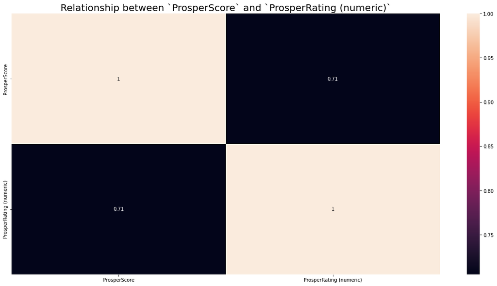

```python
color = sns.color_palette()[0]
plt.figure(figsize = (20, 10));
df = prosperLoanData[['ProsperScore', 'ProsperRating (numeric)']].corr()
sns.heatmap(data=df, annot=True)
#sns.regplot(data=prosperLoanData, x='ProsperScore', y='ProsperRating (numeric)', x_jitter=0.2, y_jitter=0.2, truncate=False, scatter_kws={'alpha': 1/30});
plt.title('Relationship between `ProsperScore` and `ProsperRating (numeric)`', fontdict={'fontsize': 20});
```

- The higher the `ProsperScore`, the higher the `ProsperRating (numeric)`
- There is a positive correlation between `ProsperScore` and `ProsperRating (numeric)`

### Question 4: Relationship between `Term` and `BorrowerState`

`Term` : The length of the loan expressed in months.

`BorrowerState` : The two letter abbreviation of the state of the address of the borrower at the time the Listing was created.

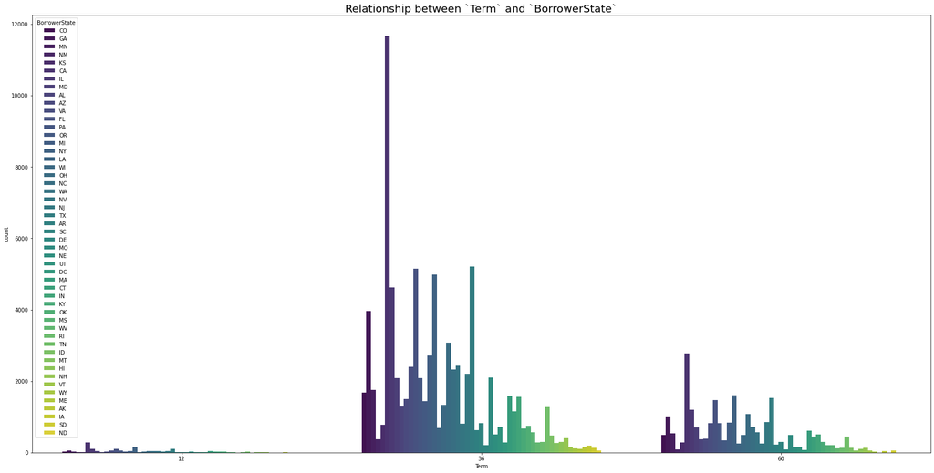

```python
plt.figure(figsize = (30, 15));
sns.countplot(data=prosperLoanData, x='Term', hue='BorrowerState', palette='viridis');
plt.title('Relationship between `Term` and `BorrowerState`', fontdict={'fontsize': 20});
```

### Question 5: Relationship between `BorrowerState` per `ProsperScore`

`BorrowerState` : The two letter abbreviation of the state of the address of the borrower at the time the Listing was created.

`ProsperScore` : A custom risk score built using historical Prosper data. The score ranges from 1-10, with 10 being the best, or lowest risk score. Applicable for loans originated after July 2009.

[figure not shown]

```python
color = sns.color_palette()[0]
plt.figure(figsize = (100, 10));
sns.countplot(data=prosperLoanData, x='BorrowerState', hue='ProsperScore', palette='viridis_r');
plt.legend(fontsize=20, loc='upper right');
plt.title('Relationship between `BorrowerState` per `ProsperScore`', fontdict={'fontsize': 20});
```

- There are five BorrowerState with Highest ProsperScore: `CA`, `FL`, `NY`, `TX` and `IL`

### Bivariate Exploration Summary

#### Question 1: Relationship between `BorrowerAPR` and `BorrowerState`

- Per each`BorrowerState`, the `BorrowerAPR` are slightly the same. There is not much difference of `BorrowerAPR` according to differents `BorrowerState`.

#### Question 2: Relationship between `ProsperRating (Alpha)` and `ProsperScore`

- Loans with high ProsperScore(like 8, 9 or 10) are associated with high ProsperRating(like B, A or AA)
- Loans with median ProsperScore(like 5, 6 or 7) are associated with low or median ProsperRating(like E, D or C)
- Loans with low ProsperScore(like 1, 2 or 4) are associated with low ProsperRating(like HR, E or D)

#### Question 5: Relationship between `BorrowerState` per `ProsperScore`

- There are five BorrowerState with Highest ProsperScore: `CA`, `FL`, `NY`, `TX` and `IL`

## Multivariate Exploration of Data

### Question 1: Relationship between `ProsperScore` and `BorrowerAPR` per `ProsperRating (Alpha)`

`ProsperScore` : A custom risk score built using historical Prosper data. The score ranges from 1-10, with 10 being the best, or lowest risk score. Applicable for loans originated after July 2009.

`BorrowerAPR` : The Borrower's Annual Percentage Rate (APR) for the loan.

`ProsperRating (Alpha)` : The Prosper Rating assigned at the time the listing was created between AA - HR. Applicable for loans originated after July 2009.

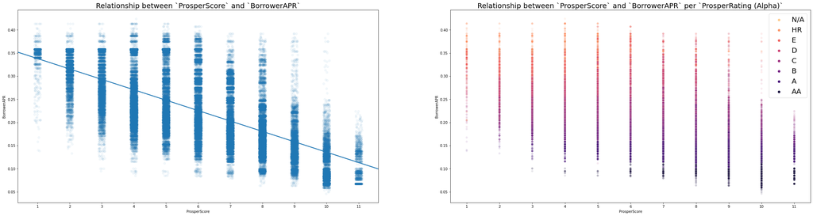

```python
color = sns.color_palette()[0]
#plt.figure(figsize = (30, 20));
#plt.suptitle('`EmploymentStatus`, `Occupation`, `EmploymentStatusDuration` and `IsBorrowerHomeowner` distribution', fontsize=20, fontweight='bold', x=0.5, y=0.92)
plt.figure(figsize = (40, 10));

plt.subplot(1, 2, 1)
sns.regplot(data=prosperLoanData, x='ProsperScore', y='BorrowerAPR', truncate=False, x_jitter=0.1, scatter_kws={'alpha': 1/20});
plt.xticks(ticks=range(1, 11 + 1), labels=[f'{i}' for i in range(1, 11 + 1)])
plt.title('Relationship between `ProsperScore` and `BorrowerAPR`', fontdict={'fontsize': 20});

plt.subplot(1, 2, 2)
sns.scatterplot(data=prosperLoanData, x='ProsperScore', y='BorrowerAPR', hue='ProsperRating (Alpha)', x_jitter=0.3, palette='magma_r', alpha=1/10);
plt.xticks(ticks=range(1, 11 + 1), labels=[f'{i}' for i in range(1, 11 + 1)])
plt.legend(fontsize=20, loc='upper right');
plt.title('Relationship between `ProsperScore` and `BorrowerAPR` per `ProsperRating (Alpha)`', fontdict={'fontsize': 20});
```

- The higher the ProsperScore the lower the BorrowerAPR. There is a neagtive correlation between these variables.
- The lower the ProsperRating is (HR or E or D) the higher the BorrowerAPR is, among every ProsperScore values
- The better the ProsperRating is (A or AA), the lower the BorrowerAPR is.
- The better the ProsperRating is (A or AA) and much more the higher the ProsperScore is (with 10 being the best, or lowest risk score), the most lower the BorrowerAPR is

### Question 2: Relationship between `ProsperScore` and `LenderYield` per `ProsperRating (Alpha)`

`ProsperScore` : A custom risk score built using historical Prosper data. The score ranges from 1-10, with 10 being the best, or lowest risk score. Applicable for loans originated after July 2009.

`LenderYield` : The Lender yield on the loan. Lender yield is equal to the interest rate on the loan less the servicing fee.

`ProsperRating (Alpha)` : The Prosper Rating assigned at the time the listing was created between AA - HR. Applicable for loans originated after July 2009.

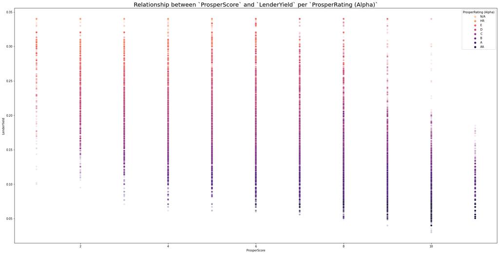

```python
plt.figure(figsize = (30, 15));
sns.scatterplot(data=prosperLoanData, x='ProsperScore', y='LenderYield', hue='ProsperRating (Alpha)', x_jitter=0.3, palette='magma_r', alpha=1/10);
plt.title('Relationship between `ProsperScore` and `LenderYield` per `ProsperRating (Alpha)`', fontdict={'fontsize': 20});
```

- The higher the `ProsperScore`, the higher the `ProsperRating (Alpha)` the lower the `LenderYield`

### Question 3: Relationship between `LoanOriginalAmount` and `BorrowerAPR` per `ProsperRating (Alpha)` per `IncomeRange`

```python
prosperLoanData['IncomeRange'].unique()
```

```
array(['$25,000-49,999', '$50,000-74,999', 'Not displayed', '$100,000+',
       '$75,000-99,999', '$1-24,999', 'Not employed', '$0'], dtype=object)
```

```python
# Let's convert IncomeRange to a CategoricalDtype
classes = ['Not displayed', 'Not employed', '$0', '$1-24,999', '$25,000-49,999', '$50,000-74,999', '$75,000-99,999', '$100,000+']
# Creating Category
cat_classes = pd.api.types.CategoricalDtype(categories=classes, ordered=True)
# Converting to CategoricalDtype
prosperLoanData['IncomeRange'] = prosperLoanData['IncomeRange'].astype(cat_classes)
# Testing
prosperLoanData['IncomeRange'].info()
```

```
<class 'pandas.core.series.Series'>
RangeIndex: 113937 entries, 0 to 113936
Series name: IncomeRange
Non-Null Count   Dtype
--------------   -----
113937 non-null  category
dtypes: category(1)
memory usage: 111.7 KB
```

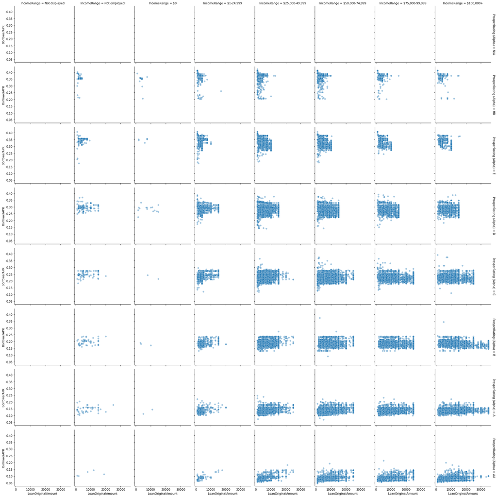

```python
plt.figure(figsize = (20, 10));
g = sns.FacetGrid(data=prosperLoanData, col='IncomeRange', row='ProsperRating (Alpha)', margin_titles=True);
g.map_dataframe(sns.scatterplot, x='LoanOriginalAmount', y='BorrowerAPR', alpha=0.4);
```

- For `IncomeRange ='Not employed'` it is really difficult to have loan with even a little amount`LoanOriginalAmount` , with even a lower `ProsperRating (Alpha)` score
- For `'IncomeRange =$0'` it is merely impossible to have a loan no matter the `ProsperRating (Alpha)` score
- The `BorrowerAPR` range tend to be lower when the `IncomeRange` tend to be higher and the `ProsperRating (Alpha)` score higher
- The `LoanOriginalAmount` range tend to be higher when the `IncomeRange` tend to be higher and the `ProsperRating (Alpha)` score higher

### Multivariate Exploration Summary

#### Question 1: Relationship between `ProsperScore` and `BorrowerAPR` per `ProsperRating (Alpha)`

- The higher the ProsperScore the lower the BorrowerAPR. There is a neagtive correlation between these variables.
- The lower the ProsperRating is (HR or E or D) the higher the BorrowerAPR is, among every ProsperScore values
- The better the ProsperRating is (A or AA), the lower the BorrowerAPR is.
- The better the ProsperRating is (A or AA) and much more the higher the ProsperScore is (with 10 being the best, or lowest risk score), the most lower the BorrowerAPR is

#### Question 2: Relationship between `ProsperScore` and `LenderYield` per `ProsperRating (Alpha)`

- The higher the `ProsperScore`, the higher the `ProsperRating (Alpha)` the lower the `LenderYield`

#### Question 3: Relationship between `LoanOriginalAmount` and `BorrowerAPR` per `ProsperRating (Alpha)` per `IncomeRange`

- For `IncomeRange ='Not employed'` it is really difficult to have loan with even a little amount`LoanOriginalAmount` , with even a lower `ProsperRating (Alpha)` score
- For `'IncomeRange =$0'` it is merely impossible to have a loan no matter the `ProsperRating (Alpha)` score
- The `BorrowerAPR` range tend to be lower when the `IncomeRange` tend to be higher and the `ProsperRating (Alpha)` score higher
- The `LoanOriginalAmount` range tend to be higher when the `IncomeRange` tend to be higher and the `ProsperRating (Alpha)` score higher

## Conclusions

### Univariate Exploration Summary

#### Question 1: What is the trend of the `LoanStatus` variable ?

- As we can see, most of the loans are ongoing `49.66%`, some are already completed `33.42%` and the less are chargedoff `10.53%`. All the other statuses are not so relevant because they have little percentages.

#### Question 2: What The most used `CreditGrade` ?

- The grade `C` is the most represented with `19.51%`
- The grade `D` is the second most represented with `17.80%`
- The grade `B` is the third most represented with `15.16%`

#### Question 3: The most contracted loan `Term` ?

- The most contracted loan term is the length of `36 months` with more than 80000 contracts.

#### Question 4: BorrowerAPR distribution

- The distribution is slightly normal
- With a standard deviation of `0.080364` the median value of the BorrowerAPR is `0.209760` and it is closest to the mean `0.218828`. It means that the BorrowerAPR is really good for loans.

#### Question 5: What is the best ProsperRating ?

The best ProsperRating is

- The grade `C` is the most represented with `21.62%` and followed by
- The grade `B` is the second most represented with `18.36%` and followed by
- The grade `A` is the third most represented with `17.15%`

#### Question 6: `ProsperScore` distribution

- The most highest `ProsperScore` are `4` then `6` then `8`. More than 12000 loans are relataed to houses with such ProsperScore.

#### Question 7: `ListingCategory` distribution

- Most of the loans are for `Debt Consolidation`. Really inspiring.

### Bivariate Exploration Summary

#### Question 1: Relationship between `BorrowerAPR` and `BorrowerState`

- Per each`BorrowerState`, the `BorrowerAPR` are slightly the same. There is not much difference of `BorrowerAPR` according to differents `BorrowerState`.

#### Question 2: Relationship between `ProsperRating (Alpha)` and `ProsperScore`

- Loans with high ProsperScore(like 8, 9 or 10) are associated with high ProsperRating(like B, A or AA)
- Loans with median ProsperScore(like 5, 6 or 7) are associated with low or median ProsperRating(like E, D or C)
- Loans with low ProsperScore(like 1, 2 or 4) are associated with low ProsperRating(like HR, E or D)

#### Question 5: Relationship between `BorrowerState` per `ProsperScore`

- There are five BorrowerState with Highest ProsperScore: `CA`, `FL`, `NY`, `TX` and `IL`

### Multivariate Exploration Summary

#### Question 1: Relationship between `ProsperScore` and `BorrowerAPR` per `ProsperRating (Alpha)`

- The higher the ProsperScore the lower the BorrowerAPR. There is a neagtive correlation between these variables.
- The lower the ProsperRating is (HR or E or D) the higher the BorrowerAPR is, among every ProsperScore values
- The better the ProsperRating is (A or AA), the lower the BorrowerAPR is.
- The better the ProsperRating is (A or AA) and much more the higher the ProsperScore is (with 10 being the best, or lowest risk score), the most lower the BorrowerAPR is

#### Question 2: Relationship between `ProsperScore` and `LenderYield` per `ProsperRating (Alpha)`

- The higher the `ProsperScore`, the higher the `ProsperRating (Alpha)` the lower the `LenderYield`

#### Question 3: Relationship between `LoanOriginalAmount` and `BorrowerAPR` per `ProsperRating (Alpha)` per `IncomeRange`

- For `IncomeRange ='Not employed'` it is really difficult to have loan with even a little amount`LoanOriginalAmount` , with even a lower `ProsperRating (Alpha)` score
- For `'IncomeRange =$0'` it is merely impossible to have a loan no matter the `ProsperRating (Alpha)` score
- The `BorrowerAPR` range tend to be lower when the `IncomeRange` tend to be higher and the `ProsperRating (Alpha)` score higher
- The `LoanOriginalAmount` range tend to be higher when the `IncomeRange` tend to be higher and the `ProsperRating (Alpha)` score higher

## Feedback

Thank you for paying attention to my work. Please I need your review to improve myself.

- What do you notice about each visualization?
- What questions do you have about the data?
- What relationships do you notice?
- What do you think is the main takeaway from the report / presentation?
- Is there anything that you don’t understand from the plots?

Kindly reach me:

- LinkedIn : [jozias-tema](https://www.linkedin.com/in/jozias-tema-496a1523a/)
- GitHub : [jozias-tema](https://github.com/temajozias/)
- Gmail : jozias-tema temajozias@gmail.com

Let's export to html and pdf

```python
from subprocess import call
call(['python', '-m', 'nbconvert', 'prosperLoanData_part1_exploratory.ipynb', '--to', 'pdf'])
```

```python
from subprocess import call
call(['python', '-m', 'nbconvert', 'prosperLoanData_part1_exploratory.ipynb', '--to', 'html'])
```